# Exercise sheet 6

Introduction to R workshop

In this session we will carry on working with the `biling_data` dataset and practice data visualisation. To avoid having to redo all data cleaning (or copypaste the code) continue working from the script you created in the previous session.

While the base `R` `plot()` function is powerful enough to create essentially any plot you might want to create, we will focus on using the `ggplot2` package. However, we’ll start with a few quick and simple base `R` plots.

## Quick plots in base `R`

### Task 1

Use the `hist()` function to plot a histogram of the `age` variable.

**Solution**

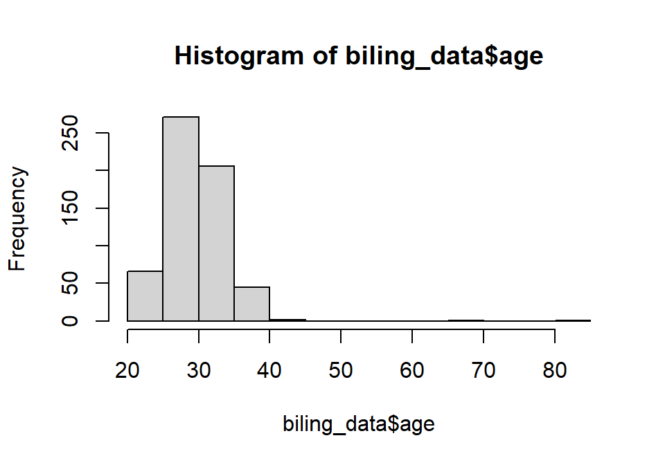

```r
hist(biling_data$age)
```

### Task 2

Use the `plot()` function to create a scatterplot of `wais` and `BILING`.

**Solution**

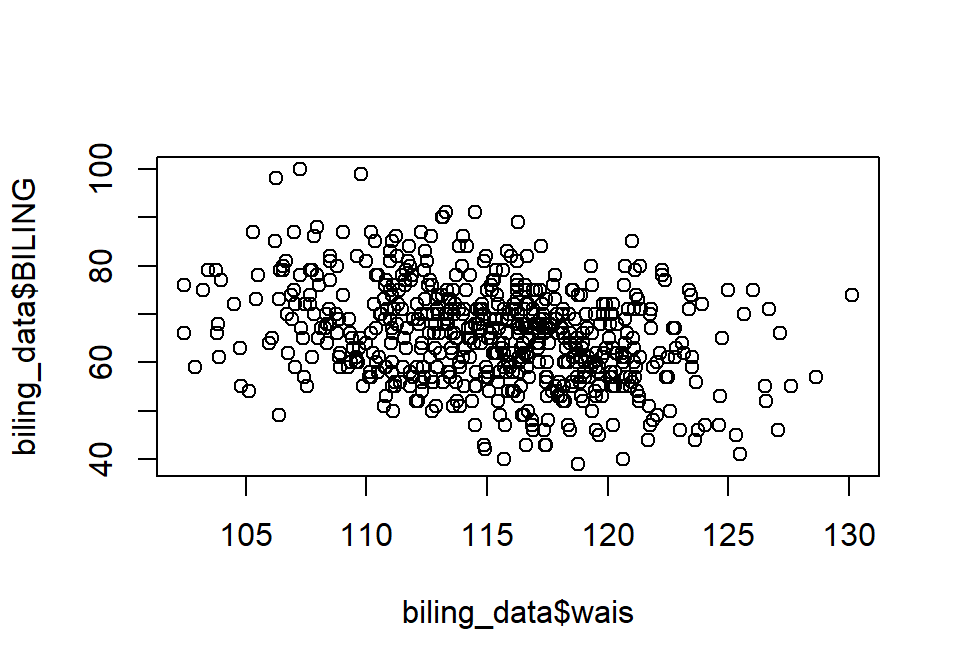

```r
plot(x = biling_data$wais, y = biling_data$BILING)
```

As you can see `plot()` tries to guess what kind of plot you want to create given the classes of the variables you pass to the function.

### Task 3

Use `plot()` again, this time with the `gender` variable only.

**Solution**

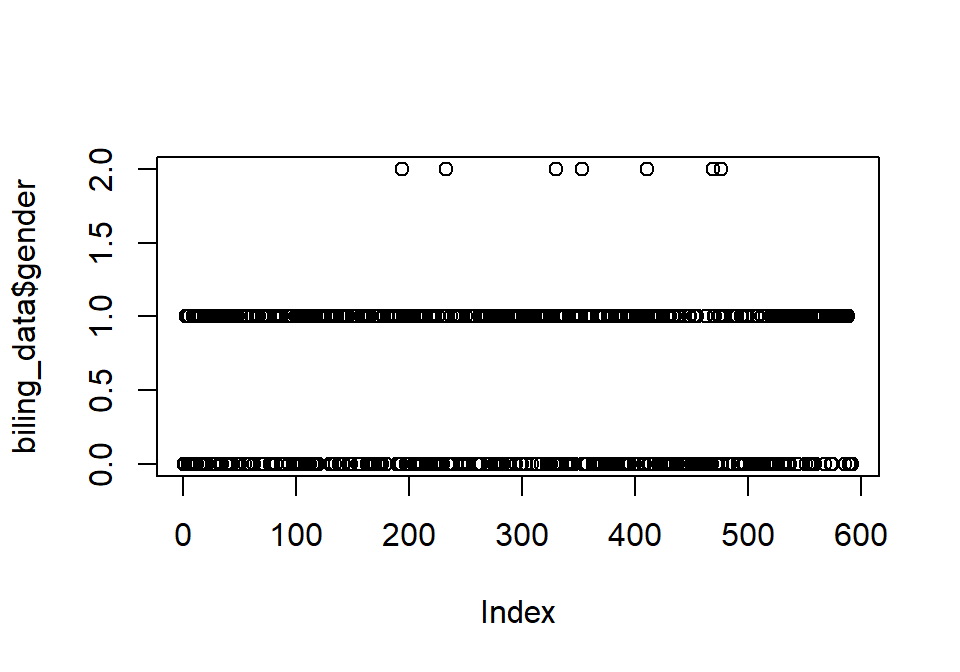

```r
plot(biling_data$gender)
```

This doesn’t look great, does it? The reason is that `gender` is has not been converted into a factor.

### Task 4

Use `plot()` again, this time with the `gender` variable only.

**Hint**

You can either turn `gender` into a factor permanently by reassigning the variable or only for the purpose of the plot inside of the `plot()` function.

**Solution**

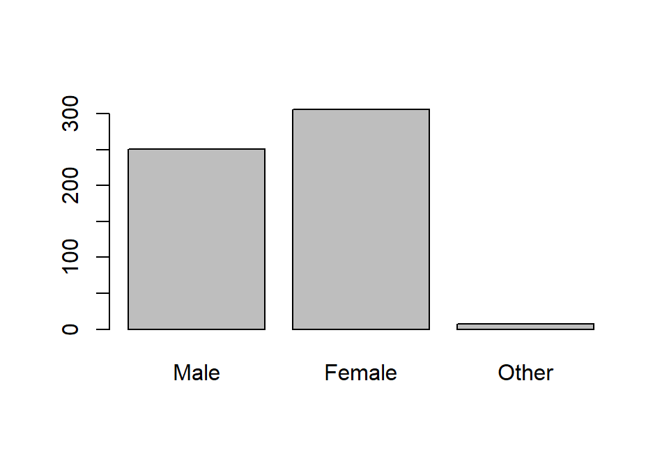

```r
# only converts gender to factor for the purpose of the plot
# plot(factor(biling_data$gender, labels = c("Male", "Female", "Other")))

# permanent change
biling_data$gender <- factor(biling_data$gender, labels = c("Male", "Female", "Other"))
plot(biling_data$gender)
```

### Task 5

Try plotting `yearsFR` by `gender`.

**Hint**

Again, just use `plot()`; it’s really rather flexible. Make sure `gender` is a factor though!

**Solution**

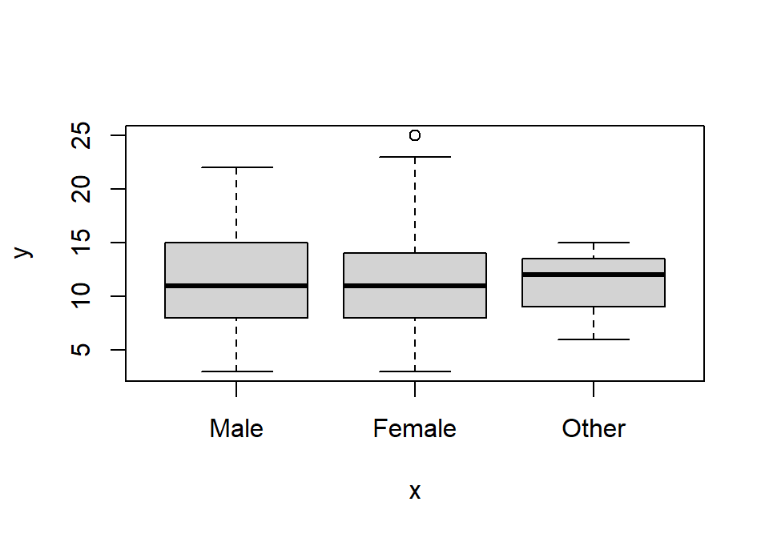

```r
plot(biling_data$gender, biling_data$yearsFR)
```

### Task 6

Finally, let’s see what plot we get when we use two factors. Plot `DALF_PASS` (as factor!) against `gender`.

**Solution**

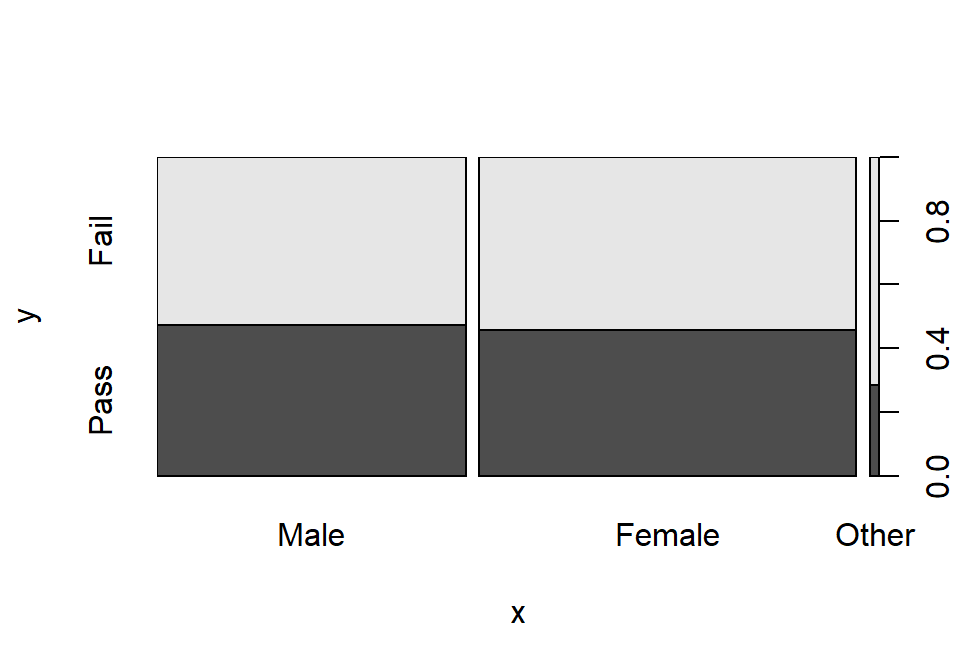

```r
biling_data$DALF_PASS <- factor(biling_data$DALF_PASS, labels = c("Fail", "Pass"))
plot(biling_data$gender, biling_data$DALF_PASS)
```

That’s a nice mosaic plot, isn’t it!

There are numerous options and arguments to the `plot()` function you can use to modify the aesthetics of the plot. Instead of dealing with those, let’s move on to `ggplot()` and leave base `R` plots with an example plot. It is not very pretty but it demonstrates some of the capabilities of base `R` graphics:

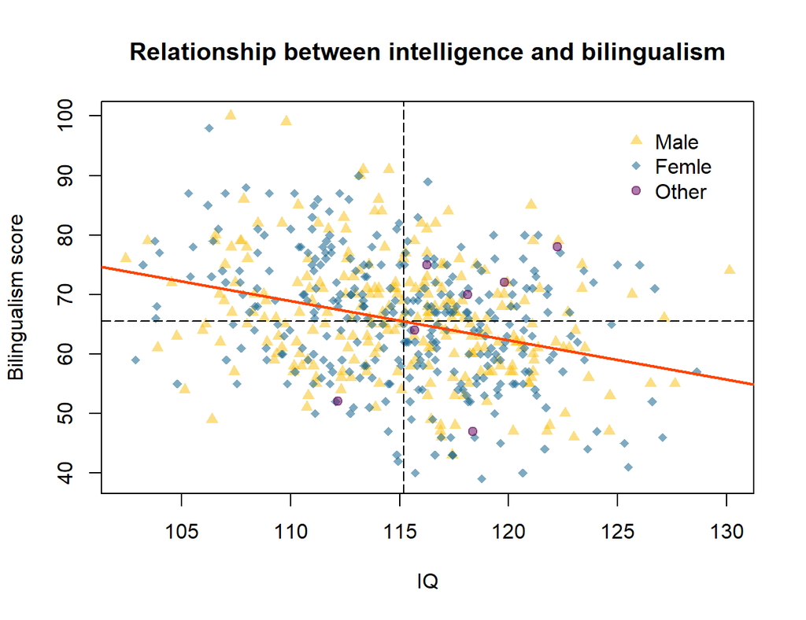

```r
plot(biling_data$wais, biling_data$BILING,
     xlab = "IQ", ylab = "Bilingualism score", # axis labels
     main = "Relationship between intelligence and bilingualism", # plot title
     type = "n") # don't plot any points
points(biling_data$wais[biling_data$gender == "Male"], # plot points for gender == "Male"
       biling_data$BILING[biling_data$gender == "Male"],
       col = "#fac21888", # hex code for colour: #RRGGBBAA - red, green, blue, alpha (opacity)
       pch = 17) # "point character" governs the shape of the point
points(biling_data$wais[biling_data$gender == "Female"], # plot points for gender == "Female"
       biling_data$BILING[biling_data$gender == "Female"],
       col = "#0d5f8a88",
       pch = 18)
points(biling_data$wais[biling_data$gender == "Other"],  # plot points for gender == "Other"
       biling_data$BILING[biling_data$gender == "Other"],
       col = "#660a6088",
       pch = 19)
abline(h = mean(biling_data$BILING), # h= y intercept of horizontal line
       lty = 5) # "line type"
abline(v = mean(biling_data$wais), lty = 5) # v= x intercept of vertical line
abline(lm(BILING ~ wais, biling_data), # abline can take a lm object to draw regression line
       col = "orangered", # there are many colour names that R understands
       lwd = 2) # "line width"
# add legend
legend(x = 125, y = 100,
       c("Male", "Femle", "Other"), # legend labels
       col = c("#fac21888", "#0d5f8a88", "#660a6088"), # colours of points in legend
       pch = 17:19, # shapes of points in legend
       bty = "n") # "box type" n for no frame around legend
```

## ggplot()

Let’s (mostly) re-create the plot above with `ggplot()` now.

### Task 7

First of all, create the plotting space mapping the right variables onto the x and y axes.

**Hint**

Remember to map variables onto axes using the `aes()` function.

**Solution**

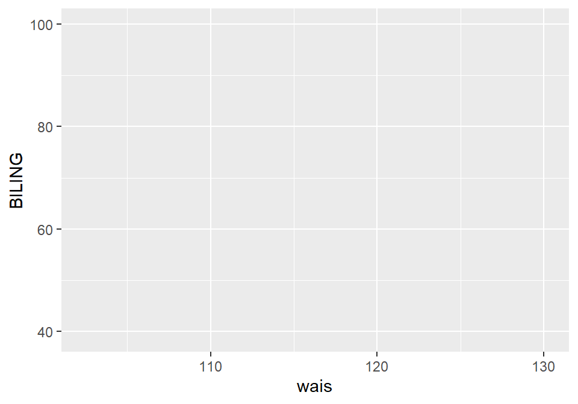

```r
biling_data %>%
  ggplot(aes(x = wais, y = BILING))
```

### Task 8

Add the scatter layer.

**Hint**

That’s `geom_point()`.

**Solution**

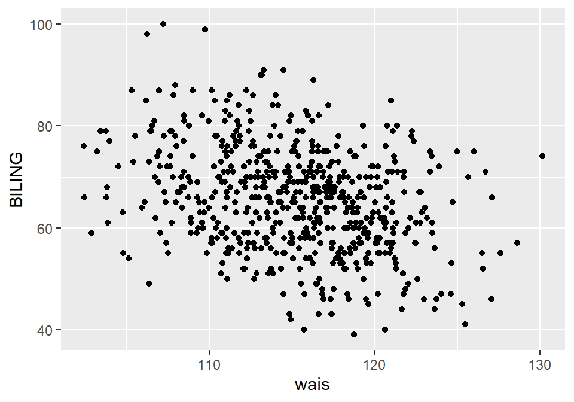

```r
biling_data %>%
  ggplot(aes(x = wais, y = BILING)) +
  geom_point()
```

#### Task 8.1

Make the colour and shape of the points dependent on levels of `gender`.

**Hint**

You can map variables onto aesthetics within `geom_point` (or any other layer).

**Solution**

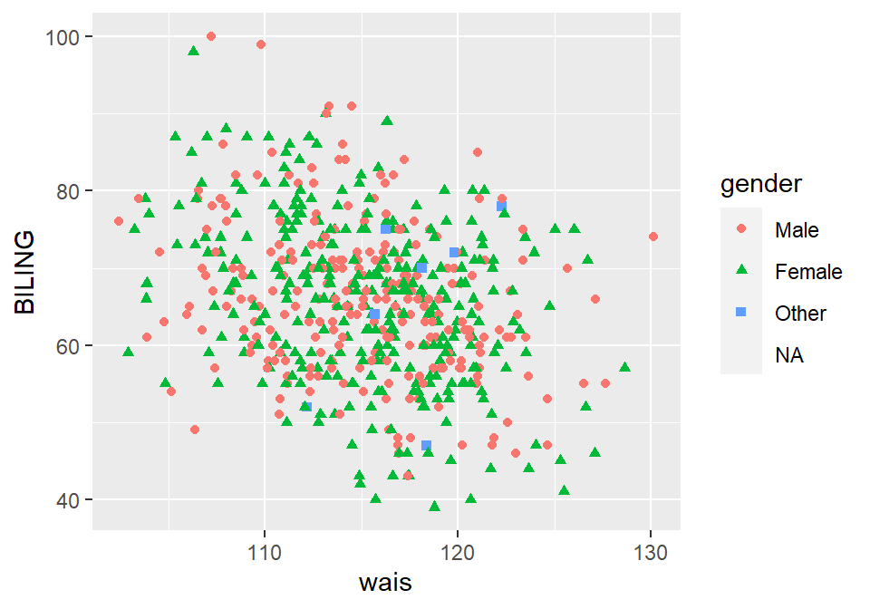

```r
biling_data %>%
  ggplot(aes(x = wais, y = BILING)) +
  geom_point(aes(colour = gender, shape = gender))
```

#### Task 8.2

Let’s get rid of the `NA` points by filtering the data so that they don’t include `NA`s in the `gender` variable before piping it into `ggplot()`.

**Hint**

`is.na(x)` returns `TRUE` if `x` is `NA`. To negate an expression, you can put a `!` in front of it.

**Solution**

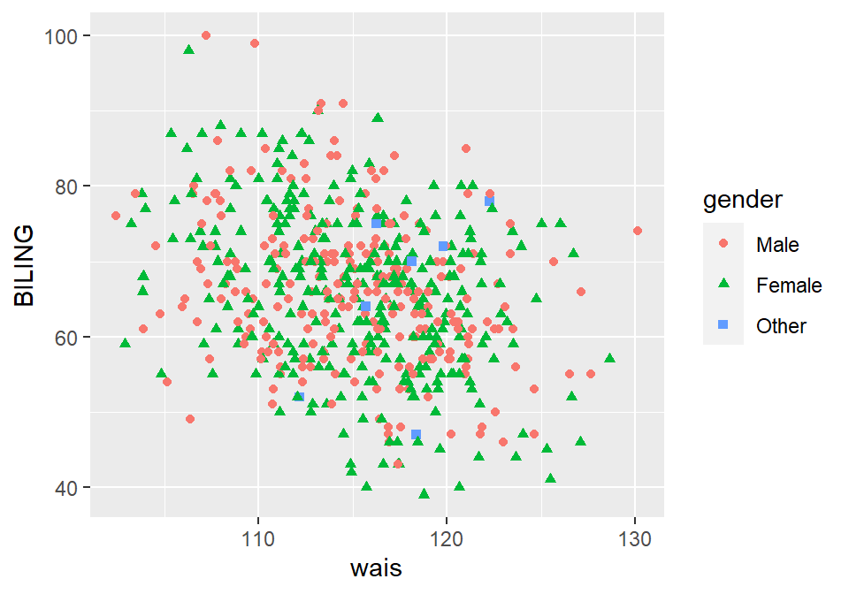

```r
biling_data %>%
  dplyr::filter(!is.na(gender)) %>%
  ggplot(aes(x = wais, y = BILING)) +
  geom_point(aes(colour = gender, shape = gender))
```

#### Task 8.3

Add a little transparency to the points using the `alpha=` argument (1 = fully opaque; 0 = fully transparent) and make the points slightly bigger.

**Hint**

You are not mapping any variables onto the `alpha=` and `size=` arguments so don’t use `aes()`.

**Solution**

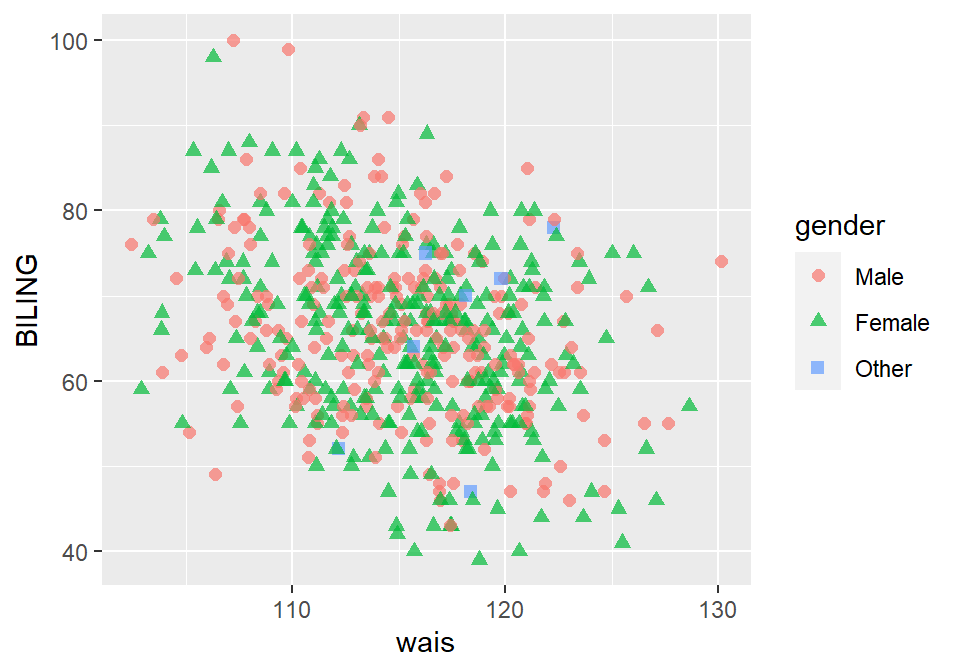

```r
biling_data %>%
  dplyr::filter(!is.na(gender)) %>%
  ggplot(aes(x = wais, y = BILING)) +
  geom_point(aes(colour = gender, shape = gender),
             alpha = .7, size = 2)
```

### Task 9

Add the horizontal dashed line with a y intercept at the mean of `BILING` using `geom_hline()`. Line geoms in `ggplot` take the same `lty=` argument as base `R` lines.

**Hint**

Because you are mapping the mean of a variable in your dataset onto `yintercept=`, it needs to be done within `aes()`.

**Solution**

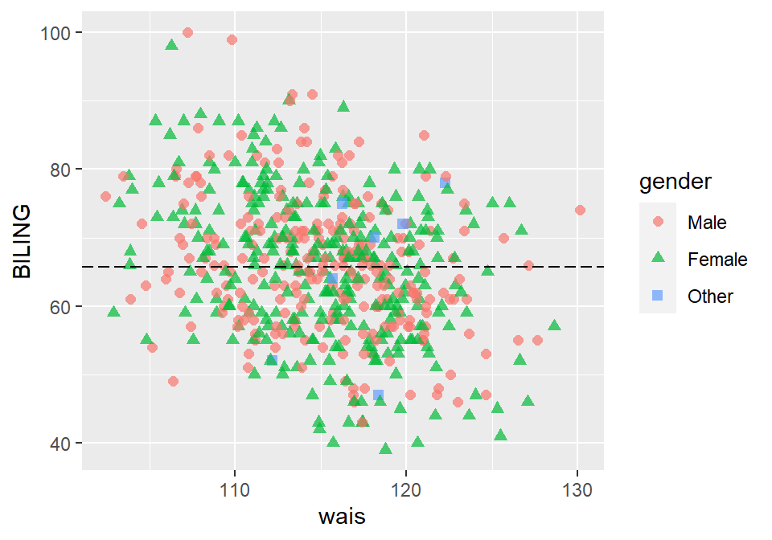

```r
biling_data %>%
  dplyr::filter(!is.na(gender)) %>%
  ggplot(aes(x = wais, y = BILING)) +
  geom_point(aes(colour = gender, shape = gender),
             alpha = .7, size = 2) +
  geom_hline(aes(yintercept = mean(BILING)), lty = 5)
```

### Task 10

Now add the vertical dashed line with a x intercept at the mean of `wais`.

**Hint**

If `geom_hline()` makes a **h**orizontal line, what geom do you think makes a **v**ertical line?

**Solution**

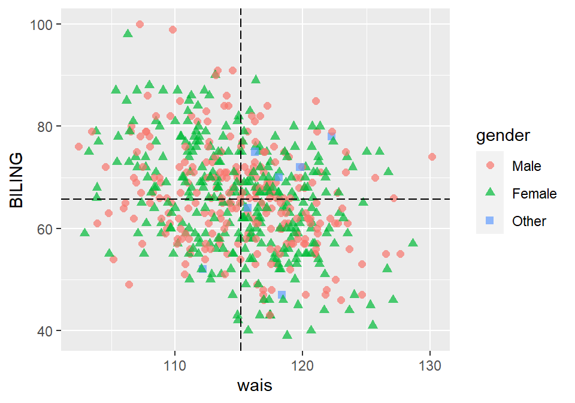

```r
biling_data %>%
  dplyr::filter(!is.na(gender)) %>%
  ggplot(aes(x = wais, y = BILING)) +
  geom_point(aes(colour = gender, shape = gender),
             alpha = .7, size = 2) +
  geom_hline(aes(yintercept = mean(BILING)), lty = 5) +
  geom_vline(aes(xintercept = mean(wais)), lty = 5)
```

### Task 11

One more element to add. Use `geom_smooth()` to add a trend line. You don’t need to specify any arguments.

**Solution**

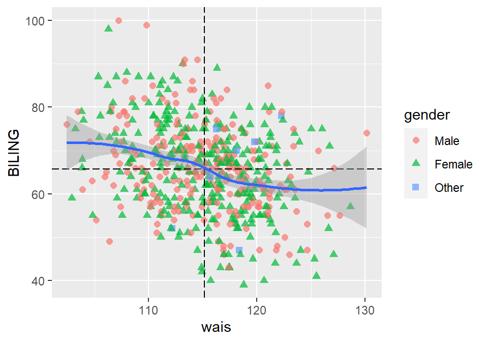

```r
biling_data %>%
  dplyr::filter(!is.na(gender)) %>%
  ggplot(aes(x = wais, y = BILING)) +
  geom_point(aes(colour = gender, shape = gender),
             alpha = .7, size = 2) +
  geom_hline(aes(yintercept = mean(BILING)), lty = 5) +
  geom_vline(aes(xintercept = mean(wais)), lty = 5) +
  geom_smooth()
```

#### Task 11.1

OK, this is a [LOESS](https://en.wikipedia.org/wiki/Local_regression) line with confidence interval ribbon. Check the function documentation (or the `ggplot2` [reference website](https://ggplot2.tidyverse.org/reference/geom_smooth.html) to find out how to change it to a linear regression line with no ribbon around it.

While you’re at it, you may as well change the colour of the line.

**Hint**

Check out the `method=` and `se=` arguments.

**Solution**

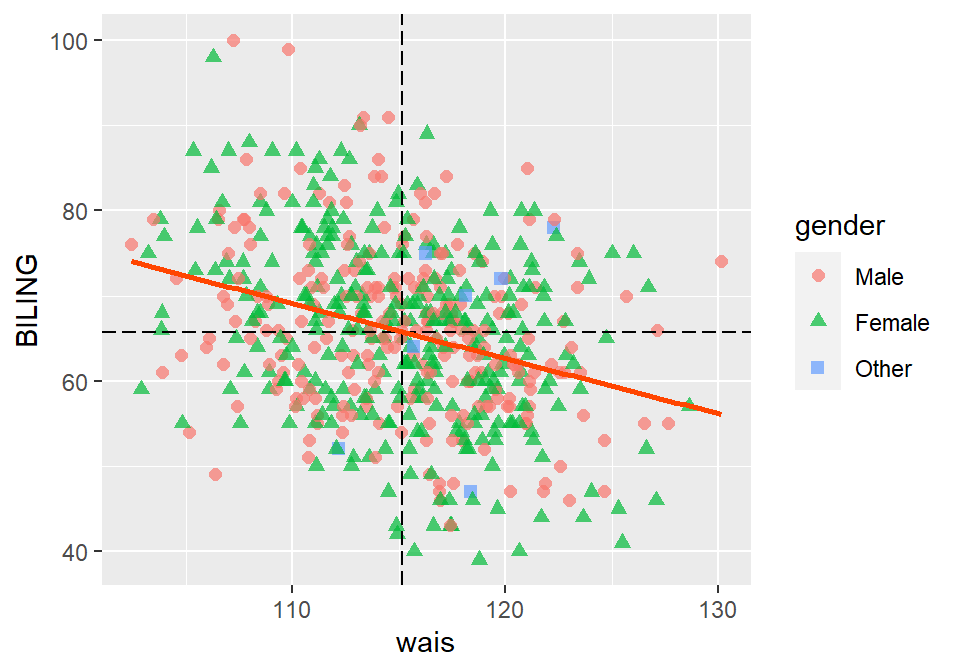

```r
biling_data %>%
  dplyr::filter(!is.na(gender)) %>%
  ggplot(aes(x = wais, y = BILING)) +
  geom_point(aes(colour = gender, shape = gender),
             alpha = .7, size = 2) +
  geom_hline(aes(yintercept = mean(BILING)), lty = 5) +
  geom_vline(aes(xintercept = mean(wais)), lty = 5) +
  geom_smooth(method = "lm", se = F, colour = "orangered")
```

### Task 12

Use the `labs()` layer to change axis labels and add title.

**Solution**

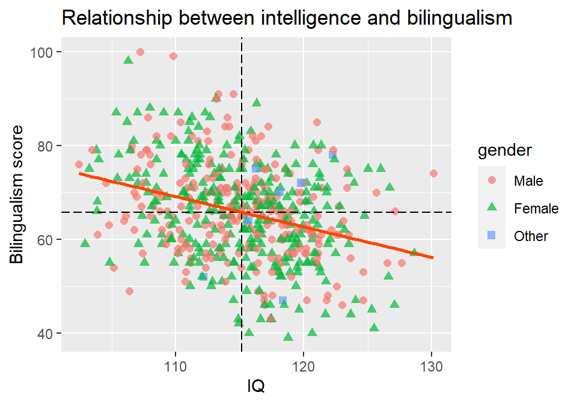

```r
biling_data %>%
  dplyr::filter(!is.na(gender)) %>%
  ggplot(aes(x = wais, y = BILING)) +
  geom_point(aes(colour = gender, shape = gender),
             alpha = .7, size = 2) +
  geom_hline(aes(yintercept = mean(BILING)), lty = 5) +
  geom_vline(aes(xintercept = mean(wais)), lty = 5) +
  geom_smooth(method = "lm", se = F, colour = "orangered") +
  labs(x = "IQ", y = "Bilingualism score",
       title = "Relationship between intelligence and bilingualism")
```

### Task 13

That’s the plot basically finished. All we need to do now is to change the appearance.

#### Task 13.1

The `scale_colour_manual()` layer can be used to customise anything to do with the colour aesthetic, including the legend. Use it to get rid of the legend name and change the colours for the gender categories to `"#fac218"`, `"#0d5f8a"`, and `"#660a60"` for males, females and “other”, respectively.

**Hint**

You only need the `name=` and `vlaues=` arguments. To get rid of the legend name, set it to an empty string, `""`.

**Solution**

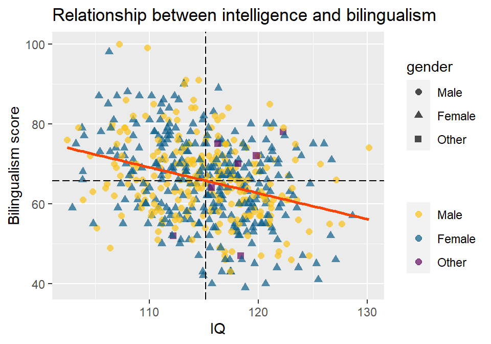

```r
biling_data %>%
  dplyr::filter(!is.na(gender)) %>%
  ggplot(aes(x = wais, y = BILING)) +
  geom_point(aes(colour = gender, shape = gender),
             alpha = .7, size = 2) +
  geom_hline(aes(yintercept = mean(BILING)), lty = 5) +
  geom_vline(aes(xintercept = mean(wais)), lty = 5) +
  geom_smooth(method = "lm", se = F, colour = "orangered") +
  labs(x = "IQ", y = "Bilingualism score",
       title = "Relationship between intelligence and bilingualism") +
  scale_colour_manual(name = "", values = c("#fac218", "#0d5f8a", "#660a60"))
```

The plot now has two legends. The reason for this is that, by changing the `name=` argument, the legend for colour is now different from the one for shape.

#### Task 13.2

Set `scale_shape_manual()` in the same fashion as above. Use values 17, 18, and 19.

**Solution**

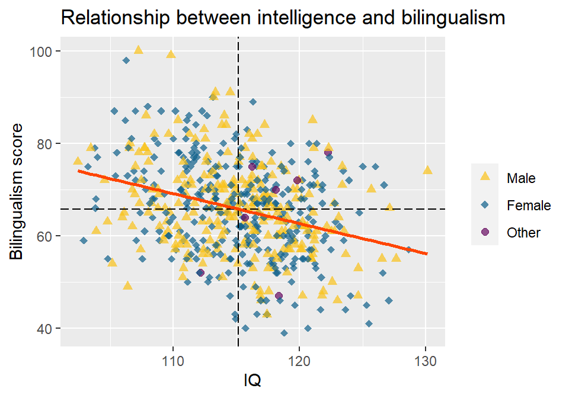

```r
biling_data %>%
  dplyr::filter(!is.na(gender)) %>%
  ggplot(aes(x = wais, y = BILING)) +
  geom_point(aes(colour = gender, shape = gender),
             alpha = .7, size = 2) +
  geom_hline(aes(yintercept = mean(BILING)), lty = 5) +
  geom_vline(aes(xintercept = mean(wais)), lty = 5) +
  geom_smooth(method = "lm", se = F, colour = "orangered") +
  labs(x = "IQ", y = "Bilingualism score",
       title = "Relationship between intelligence and bilingualism") +
  scale_colour_manual(name = "", values = c("#fac218", "#0d5f8a", "#660a60")) +
  scale_shape_manual(name = "", values = 17:19)
```

As you can see, the legends have now merged into one.

### Task 14

Let’s give the plot a little more of a classic look by adding a theme layer.

**Hint**

Just add a `theme_classic()` layer.

**Solution**

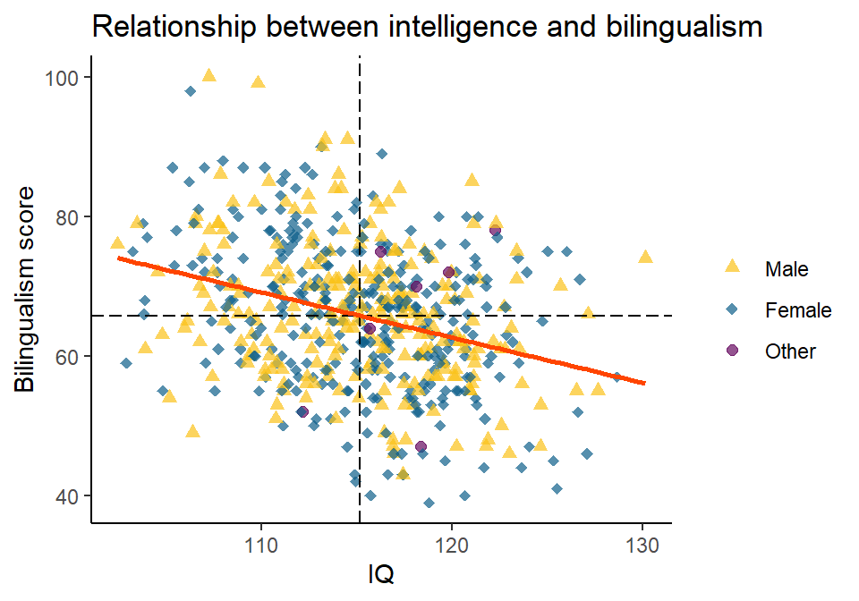

```r
biling_data %>%
  dplyr::filter(!is.na(gender)) %>%
  ggplot(aes(x = wais, y = BILING)) +
  geom_point(aes(colour = gender, shape = gender),
             alpha = .7, size = 2) +
  geom_hline(aes(yintercept = mean(BILING)), lty = 5) +
  geom_vline(aes(xintercept = mean(wais)), lty = 5) +
  geom_smooth(method = "lm", se = F, colour = "orangered") +
  labs(x = "IQ", y = "Bilingualism score",
       title = "Relationship between intelligence and bilingualism") +
  scale_colour_manual(name = "", values = c("#fac218", "#0d5f8a", "#660a60")) +
  scale_shape_manual(name = "", values = 17:19) +
  theme_classic()
```

Looking at the plot, maybe it would be a little better if the dashed lines were behind the points rather than on top of them.

#### Task 14.1

Hide the dashed lines behind the scatter.

**Hint**

Simply rearrange the order of your geoms.

**Solution**

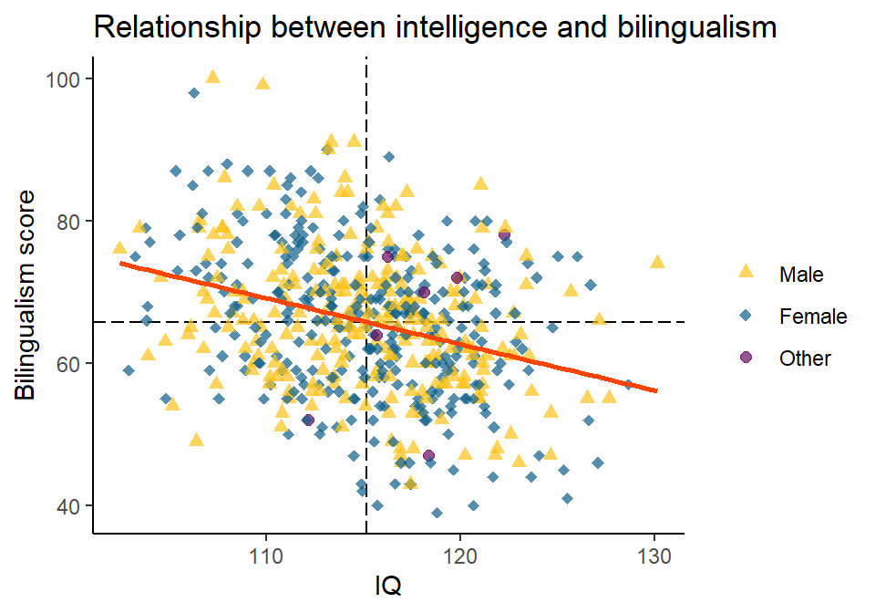

```r
biling_data %>%
  dplyr::filter(!is.na(gender)) %>%
  ggplot(aes(x = wais, y = BILING)) +
  geom_hline(aes(yintercept = mean(BILING)), lty = 5) +
  geom_vline(aes(xintercept = mean(wais)), lty = 5) +
  geom_point(aes(colour = gender, shape = gender),
             alpha = .7, size = 2) +
  geom_smooth(method = "lm", se = F, colour = "orangered") +
  labs(x = "IQ", y = "Bilingualism score",
       title = "Relationship between intelligence and bilingualism") +
  scale_colour_manual(name = "", values = c("#fac218", "#0d5f8a", "#660a60")) +
  scale_shape_manual(name = "", values = 17:19) +
  theme_classic()
```

### Task 15

A task for the brave! Can you figure out how to change the position of the legend to make the plot look like this?

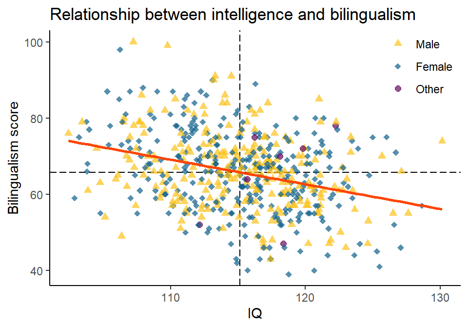

**Hint**

The Internet is your friend.

**Solution**

```r
... + theme(legend.position = c(.9, .9))
```

### Task 16

Save your lovely plot using `ggsave()`.

**Solution**

```r
# by default ggsave() saves the last plot
ggsave(filename = "my_rad_scatterplot.png")

# you can assign a plot to an object and save it using the object's name
p <- biling_data %>%
  dplyr::filter(!is.na(gender)) %>%
  ggplot(aes(x = wais, y = BILING)) +
  geom_hline(aes(yintercept = mean(BILING)), lty = 5) +
  geom_vline(aes(xintercept = mean(wais)), lty = 5) +
  geom_point(aes(colour = gender, shape = gender),
             alpha = .7, size = 2) +
  geom_smooth(method = "lm", se = F, colour = "orangered") +
  labs(x = "IQ", y = "Bilingualism score",
       title = "Relationship between intelligence and bilingualism") +
  scale_colour_manual(name = "", values = c("#fac218", "#0d5f8a", "#660a60")) +
  scale_shape_manual(name = "", values = 17:19) +
  theme_classic() +
  theme(legend.position = c(.9, .9))

ggsave(filename = "my_rad_scatterplot.png", plot = p)
```

## Reflect

That was quite a lot of plotting! Let’s pause to think about all the things we’ve covered.

In this session, you:

- practised creating quick exploratory plots using base `R`
- saw how `plot()` picks different visualisations based on the number and classes of the variables you provide it
- built a rather advanced grouped scatterplot using `ggplot()` and
  - `geom_point()` for adding, well, points.
  - `geom_smooth()` for adding trend lines
  - `geom_hline()` and `geom_vline()` for horizontal and vertical lines, respectively
- learnt how to customise the appearance of the plot to your (well, mine, really) taste with
  - `labs()`
  - `scale_..._manual()`
  - `theme()`
- solidified your understanding of principles of `ggplot()`:
  - when to use `aes()` and when not to
  - plots are composed of layers and the order of layers matters